# Generación de variables aleatorias geométricas

**Integrantes**

- 2172016 - Kevin Javier Lozano Galvis
- 2170688 - Brayan Rodolfo Barajas Ochoa
- 2161342 - Carlos Alberto Palencia Pombo

Recordemos que se dice que X es una variable aleatoria geométrica con el parámetro p si

$$P\left\lbrace{X = i}\right\rbrace = pq^{i-1},\; i \geq 1,\; donde\ q=1-p$$

Se puede pensar que X representa el momento del primer éxito cuando se realizan ensayos independientes, cada uno de los cuales es un éxito con probabilidad p. Desde

$$\sum_{i=1}^{j-1}p\{X=i\} = 1 - p\left\lbrace{X > j-1}\right\rbrace$$
$$= 1-p \left\lbrace{Las\ primeras\ pruebas\ de\ j-1\ son\ todas\ fallas}\right\rbrace$$

$$= 1 - q^{j-1},\ j\leq1$$

O, de forma equivalente, para el cual

$$q^{j} < 1 - U \leq q^{j-1}$$

Es decir, podemos definir X por
$$X = Min\{j:q^j <1-U\}$$

Por lo tanto, usando el hecho de que el logaritmo es una función monótona, por lo que $a<b$ es equivalente a $log(a)<log(b)$, obtenemos que $X$ se puede expresar como:

$$X = Min\{j : j\ log(q) < log(1 - U)\}$$
$$= Min \left\lbrace{ j:j > \frac{log(1-U)}{log(q)}}\right\rbrace$$

Donde la última desigualdad cambió de signo porque $log(q)$ es negativo para $0 < q < 1$. Por lo tanto, usando la notación Int() podemos expresar $X$ como

$$X = int\left(\frac{log(1-U)}{log(q)}\right) + 1$$

Por último, al observar que $1-U$ también está uniformemente distribuido en (0,1), se deduce que

$$X \equiv int\left(\frac{log(U)}{log(q)}\right) + 1$$

también es geométrico con el parámetro p.

A continuación, se implementa esto como una función en R para generar la variable aleatoria geométrica, teniendo como parámetros n (número de valores a generar) y p.

```r
geometric.gen<-function(n,p){
  r=integer(n)
  q=1-p
  u=runif(n)
  r=as.integer((log(u)/log(q))+1)
  return(r)
}
```

Al probarla, se obtiene el siguiente resultado:

```r
nums<-geometric.gen(10,1/6)
print(nums)
```

```
##  [1] 3 3 7 4 3 7 6 4 1 4
```

Para visualizar si los números que se generan siguen la distribución geométrica, se realiza lo siguiente:

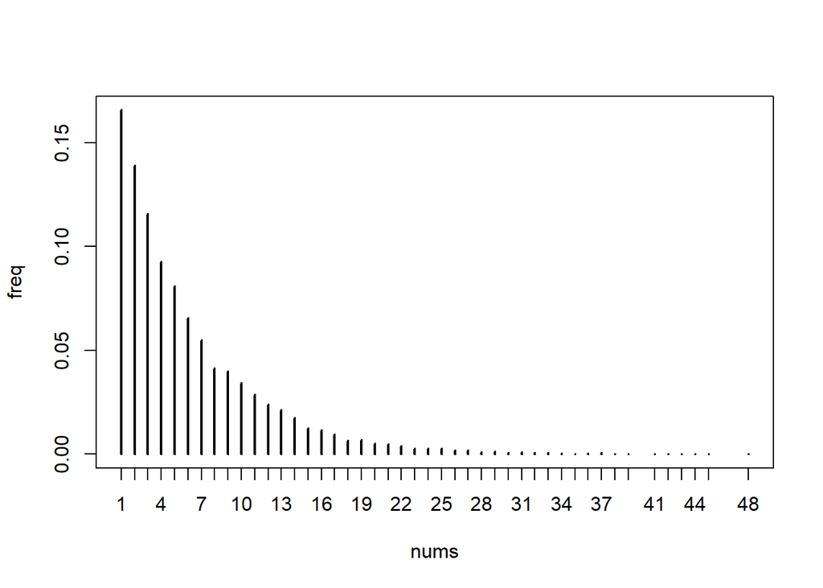

```r
nums<-geometric.gen(10000,1/6)
freq <- prop.table(table(nums))
  plot(freq)
```

Y se compara con la gráfica de densidad de la distribución geométrica.

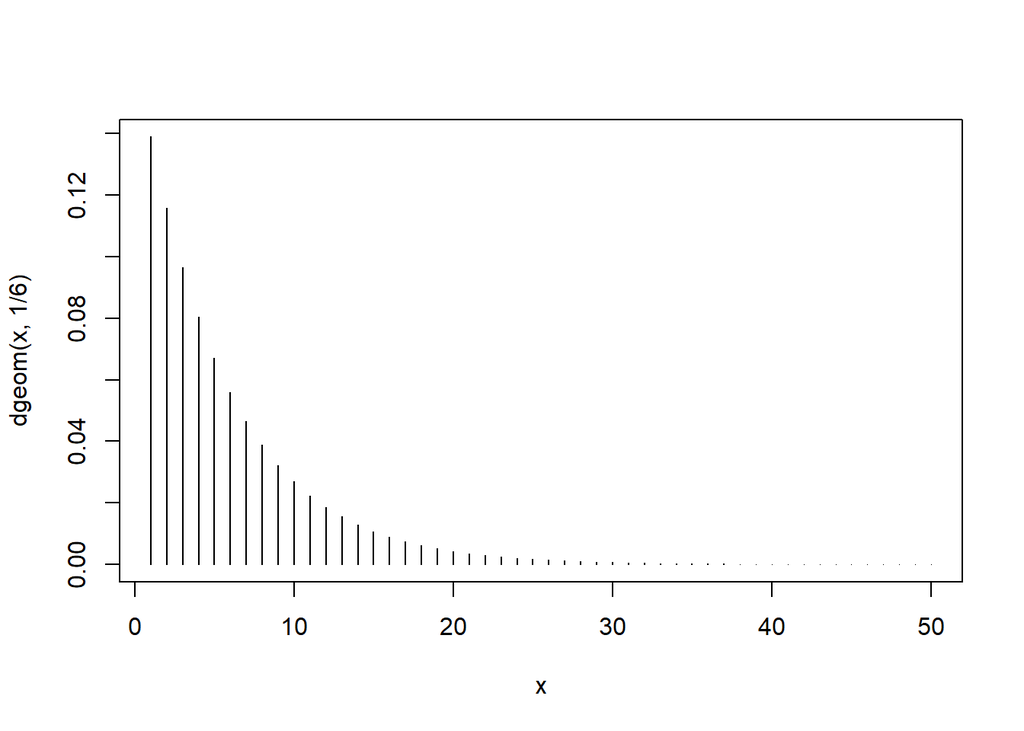

```r
 x <- seq(50)
  plot(x, dgeom(x,1/6), "h")
```